# **Lab 2: Studying Universal Approximation in Neural Networks**

**@author : Maelwenn LABIDURIE & Albane COIFFE**  
**@email : maelwenn.labidurie@efrei.net & albane.coiffe@efrei.net**  
18/09/2024

## **Objective**

```python
import numpy as np
from sklearn.metrics import confusion_matrix, classification_report
import matplotlib.pyplot as plt
```

```python
import tensorflow as tf
from tensorflow.keras import layers, models
```

```
2024-09-18 15:59:28.944733: I tensorflow/core/platform/cpu_feature_guard.cc:210] This TensorFlow binary is optimized to use available CPU instructions in performance-critical operations.
To enable the following instructions: AVX2 FMA, in other operations, rebuild TensorFlow with the appropriate compiler flags.
```

## **Step 1: Data Generation**

### 1. Define the function ( 𝑓(𝑥) as follows:

𝑓(𝑥) = {  
𝑠𝑖𝑛(𝜋 𝑥) 𝑖𝑓 𝑥 ∈ ] − 1, 1 [  
0 𝑖𝑓 𝑥 ∈ [−2, −1] ∪ [1, 2]

```python
# Function definition
def f(x):
    if -1 < x < 1:
        return np.sin(np.pi * x)
    else:
        return 0
```

### 2. Add noise 𝒩(0, 0.2) to the data.

```python
# Generate data
np.random.seed(42)
```

`np.random.normal(0, 0.2)`  
Cette fonction va ajouter tu bruit a nos données générer au dessus, suivant une loi normale de moyenne 0 et d'écart tupe 0.2, comme demander dans le TP.

### 3. Generate multiple training and test samples using this function.

```python
x_train = np.random.uniform(-2, 2, 1000)
y_train = np.array([f(x) + np.random.normal(0, 0.2) for x in x_train])
```

```python
# For test set
x_test = np.random.uniform(-2, 2, 200)
y_test = np.array([f(x) + np.random.normal(0, 0.2) for x in x_test])
```

## **Step 2: MLP Implementation with TensorFlow**

In this step, we will train a simple MLP with one hidden layer on the generated data. You can use the following Python code with TensorFlow to implement the MLP:

```python
# Model definition
model = models.Sequential()
model.add(layers.Dense(10, activation='tanh', input_shape=(1,))) # Hidden layer with tanh
model.add(layers.Dense(1)) # Output layer with no activation function
```

```python
# Compile the model
model.compile(optimizer='adam', loss='mean_squared_error')
```

```python
# Train the model
model.fit(x_train, y_train, epochs=100, batch_size=32, validation_data=(x_test, y_test))
```

```
32/32 ━━━━━━━━━━━━━━━━━━━━ 1s 7ms/step - loss: 0.2788 - val_loss: 0.3216
32/32 ━━━━━━━━━━━━━━━━━━━━ 0s 2ms/step - loss: 0.2637 - val_loss: 0.3173
32/32 ━━━━━━━━━━━━━━━━━━━━ 0s 2ms/step - loss: 0.2681 - val_loss: 0.3129
32/32 ━━━━━━━━━━━━━━━━━━━━ 0s 2ms/step - loss: 0.2453 - val_loss: 0.3061
32/32 ━━━━━━━━━━━━━━━━━━━━ 0s 2ms/step - loss: 0.2481 - val_loss: 0.3013
32/32 ━━━━━━━━━━━━━━━━━━━━ 0s 2ms/step - loss: 0.2624 - val_loss: 0.2986
32/32 ━━━━━━━━━━━━━━━━━━━━ 0s 3ms/step - loss: 0.2520 - val_loss: 0.2933
32/32 ━━━━━━━━━━━━━━━━━━━━ 0s 2ms/step - loss: 0.2457 - val_loss: 0.2883
32/32 ━━━━━━━━━━━━━━━━━━━━ 0s 2ms/step - loss: 0.2349 - val_loss: 0.2809
32/32 ━━━━━━━━━━━━━━━━━━━━ 0s 2ms/step - loss: 0.2307 - val_loss: 0.2790
32/32 ━━━━━━━━━━━━━━━━━━━━ 0s 2ms/step - loss: 0.2210 - val_loss: 0.2693
32/32 ━━━━━━━━━━━━━━━━━━━━ 0s 2ms/step - loss: 0.2344 - val_loss: 0.2658
32/32 ━━━━━━━━━━━━━━━━━━━━ 0s 2ms/step - loss: 0.2245 - val_loss: 0.2592
32/32 ━━━━━━━━━━━━━━━━━━━━ 0s 2ms/step - loss: 0.2146 - val_loss: 0.2553
32/32 ━━━━━━━━━━━━━━━━━━━━ 0s 2ms/step - loss: 0.2056 - val_loss: 0.2477
32/32 ━━━━━━━━━━━━━━━━━━━━ 0s 2ms/step - loss: 0.2106 - val_loss: 0.2452
32/32 ━━━━━━━━━━━━━━━━━━━━ 0s 2ms/step - loss: 0.2021 - val_loss: 0.2389
32/32 ━━━━━━━━━━━━━━━━━━━━ 0s 2ms/step - loss: 0.1967 - val_loss: 0.2319
32/32 ━━━━━━━━━━━━━━━━━━━━ 0s 2ms/step - loss: 0.1875 - val_loss: 0.2269
32/32 ━━━━━━━━━━━━━━━━━━━━ 0s 2ms/step - loss: 0.1847 - val_loss: 0.2192
32/32 ━━━━━━━━━━━━━━━━━━━━ 0s 2ms/step - loss: 0.1840 - val_loss: 0.2174
32/32 ━━━━━━━━━━━━━━━━━━━━ 0s 2ms/step - loss: 0.1731 - val_loss: 0.2090
32/32 ━━━━━━━━━━━━━━━━━━━━ 0s 2ms/step - loss: 0.1657 - val_loss: 0.2037
32/32 ━━━━━━━━━━━━━━━━━━━━ 0s 2ms/step - loss: 0.1659 - val_loss: 0.1988
32/32 ━━━━━━━━━━━━━━━━━━━━ 0s 5ms/step - loss: 0.1655 - val_loss: 0.1934
32/32 ━━━━━━━━━━━━━━━━━━━━ 0s 2ms/step - loss: 0.1665 - val_loss: 0.1880
32/32 ━━━━━━━━━━━━━━━━━━━━ 0s 2ms/step - loss: 0.1567 - val_loss: 0.1831
32/32 ━━━━━━━━━━━━━━━━━━━━ 0s 2ms/step - loss: 0.1664 - val_loss: 0.1769
32/32 ━━━━━━━━━━━━━━━━━━━━ 0s 2ms/step - loss: 0.1581 - val_loss: 0.1711
32/32 ━━━━━━━━━━━━━━━━━━━━ 0s 2ms/step - loss: 0.1508 - val_loss: 0.1664
32/32 ━━━━━━━━━━━━━━━━━━━━ 0s 2ms/step - loss: 0.1433 - val_loss: 0.1622
32/32 ━━━━━━━━━━━━━━━━━━━━ 0s 2ms/step - loss: 0.1426 - val_loss: 0.1583
32/32 ━━━━━━━━━━━━━━━━━━━━ 0s 2ms/step - loss: 0.1403 - val_loss: 0.1527
32/32 ━━━━━━━━━━━━━━━━━━━━ 0s 2ms/step - loss: 0.1330 - val_loss: 0.1498
32/32 ━━━━━━━━━━━━━━━━━━━━ 0s 2ms/step - loss: 0.1280 - val_loss: 0.1458
32/32 ━━━━━━━━━━━━━━━━━━━━ 0s 2ms/step - loss: 0.1305 - val_loss: 0.1421
32/32 ━━━━━━━━━━━━━━━━━━━━ 0s 2ms/step - loss: 0.1216 - val_loss: 0.1396
32/32 ━━━━━━━━━━━━━━━━━━━━ 0s 2ms/step - loss: 0.1224 - val_loss: 0.1366
32/32 ━━━━━━━━━━━━━━━━━━━━ 0s 2ms/step - loss: 0.1219 - val_loss: 0.1357
32/32 ━━━━━━━━━━━━━━━━━━━━ 0s 2ms/step - loss: 0.1233 - val_loss: 0.1293
```

[output cut: 45 more lines]

```
32/32 ━━━━━━━━━━━━━━━━━━━━ 0s 2ms/step - loss: 0.0701 - val_loss: 0.0783
32/32 ━━━━━━━━━━━━━━━━━━━━ 0s 2ms/step - loss: 0.0743 - val_loss: 0.0780
32/32 ━━━━━━━━━━━━━━━━━━━━ 0s 2ms/step - loss: 0.0760 - val_loss: 0.0756
32/32 ━━━━━━━━━━━━━━━━━━━━ 0s 2ms/step - loss: 0.0710 - val_loss: 0.0764
32/32 ━━━━━━━━━━━━━━━━━━━━ 0s 2ms/step - loss: 0.0705 - val_loss: 0.0751
32/32 ━━━━━━━━━━━━━━━━━━━━ 0s 2ms/step - loss: 0.0705 - val_loss: 0.0758
32/32 ━━━━━━━━━━━━━━━━━━━━ 0s 2ms/step - loss: 0.0711 - val_loss: 0.0746
32/32 ━━━━━━━━━━━━━━━━━━━━ 0s 2ms/step - loss: 0.0715 - val_loss: 0.0738
32/32 ━━━━━━━━━━━━━━━━━━━━ 0s 2ms/step - loss: 0.0689 - val_loss: 0.0755
32/32 ━━━━━━━━━━━━━━━━━━━━ 0s 2ms/step - loss: 0.0669 - val_loss: 0.0717
32/32 ━━━━━━━━━━━━━━━━━━━━ 0s 2ms/step - loss: 0.0722 - val_loss: 0.0740
32/32 ━━━━━━━━━━━━━━━━━━━━ 0s 2ms/step - loss: 0.0636 - val_loss: 0.0695
32/32 ━━━━━━━━━━━━━━━━━━━━ 0s 2ms/step - loss: 0.0664 - val_loss: 0.0709
32/32 ━━━━━━━━━━━━━━━━━━━━ 0s 2ms/step - loss: 0.0670 - val_loss: 0.0703
32/32 ━━━━━━━━━━━━━━━━━━━━ 0s 2ms/step - loss: 0.0642 - val_loss: 0.0707
```

```
<keras.src.callbacks.history.History at 0x1562d49d0>
```

```python
y_pred = model.predict(x_test)
```

```
7/7 ━━━━━━━━━━━━━━━━━━━━ 0s 786us/step
```

### Visualisation du modele

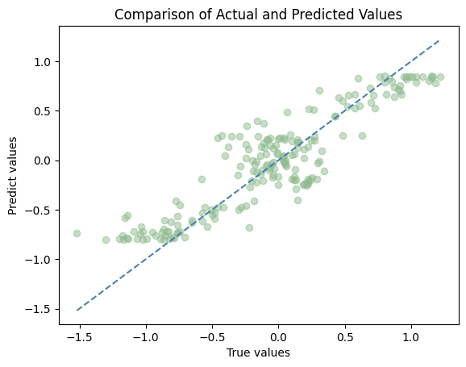

```python
plt.scatter(y_test, y_pred, alpha=0.5, color="darkseagreen")
plt.plot([min(y_test), max(y_test)], [min(y_test), max(y_test)], color='steelblue', linestyle='--')
plt.xlabel('True values')
plt.ylabel('Predict values')
plt.title('Comparison of Actual and Predicted Values')
plt.show()
```

Nous pouvons voir que le modèle fait des projection plutot bonne qui suivent l'axe x=y.

## **Recommendations**

#### Observation 1 (Avec 1 neuronne)

```python
# Model definition
model = models.Sequential()
model.add(layers.Dense(1, activation='tanh', input_shape=(1,))) # Hidden layer with tanh
model.add(layers.Dense(1)) # Output layer with no activation function
# Compile the model
model.compile(optimizer='adam', loss='mean_squared_error')
# Train the model
model.fit(x_train, y_train, epochs=100, batch_size=32, validation_data=(x_test, y_test))
```

```
32/32 ━━━━━━━━━━━━━━━━━━━━ 1s 4ms/step - loss: 0.7810 - val_loss: 0.9023
32/32 ━━━━━━━━━━━━━━━━━━━━ 0s 1ms/step - loss: 0.7776 - val_loss: 0.8574
32/32 ━━━━━━━━━━━━━━━━━━━━ 0s 1ms/step - loss: 0.7295 - val_loss: 0.8159
32/32 ━━━━━━━━━━━━━━━━━━━━ 0s 1ms/step - loss: 0.6608 - val_loss: 0.7776
32/32 ━━━━━━━━━━━━━━━━━━━━ 0s 1ms/step - loss: 0.6811 - val_loss: 0.7413
32/32 ━━━━━━━━━━━━━━━━━━━━ 0s 1ms/step - loss: 0.6596 - val_loss: 0.7080
32/32 ━━━━━━━━━━━━━━━━━━━━ 0s 1ms/step - loss: 0.5810 - val_loss: 0.6765
32/32 ━━━━━━━━━━━━━━━━━━━━ 0s 1ms/step - loss: 0.5552 - val_loss: 0.6476
32/32 ━━━━━━━━━━━━━━━━━━━━ 0s 1ms/step - loss: 0.5221 - val_loss: 0.6206
32/32 ━━━━━━━━━━━━━━━━━━━━ 0s 1ms/step - loss: 0.5032 - val_loss: 0.5954
32/32 ━━━━━━━━━━━━━━━━━━━━ 0s 1ms/step - loss: 0.4768 - val_loss: 0.5722
32/32 ━━━━━━━━━━━━━━━━━━━━ 0s 1ms/step - loss: 0.4490 - val_loss: 0.5512
32/32 ━━━━━━━━━━━━━━━━━━━━ 0s 1ms/step - loss: 0.4408 - val_loss: 0.5310
32/32 ━━━━━━━━━━━━━━━━━━━━ 0s 1ms/step - loss: 0.4096 - val_loss: 0.5126
32/32 ━━━━━━━━━━━━━━━━━━━━ 0s 1ms/step - loss: 0.4145 - val_loss: 0.4961
32/32 ━━━━━━━━━━━━━━━━━━━━ 0s 1ms/step - loss: 0.3956 - val_loss: 0.4807
32/32 ━━━━━━━━━━━━━━━━━━━━ 0s 1ms/step - loss: 0.3695 - val_loss: 0.4671
32/32 ━━━━━━━━━━━━━━━━━━━━ 0s 1ms/step - loss: 0.3794 - val_loss: 0.4541
32/32 ━━━━━━━━━━━━━━━━━━━━ 0s 1ms/step - loss: 0.3721 - val_loss: 0.4422
32/32 ━━━━━━━━━━━━━━━━━━━━ 0s 1ms/step - loss: 0.3622 - val_loss: 0.4310
32/32 ━━━━━━━━━━━━━━━━━━━━ 0s 1ms/step - loss: 0.3459 - val_loss: 0.4216
32/32 ━━━━━━━━━━━━━━━━━━━━ 0s 1ms/step - loss: 0.3376 - val_loss: 0.4118
32/32 ━━━━━━━━━━━━━━━━━━━━ 0s 1ms/step - loss: 0.3131 - val_loss: 0.4032
32/32 ━━━━━━━━━━━━━━━━━━━━ 0s 1ms/step - loss: 0.3349 - val_loss: 0.3956
32/32 ━━━━━━━━━━━━━━━━━━━━ 0s 1ms/step - loss: 0.3020 - val_loss: 0.3888
32/32 ━━━━━━━━━━━━━━━━━━━━ 0s 1ms/step - loss: 0.3197 - val_loss: 0.3822
32/32 ━━━━━━━━━━━━━━━━━━━━ 0s 1ms/step - loss: 0.2854 - val_loss: 0.3764
32/32 ━━━━━━━━━━━━━━━━━━━━ 0s 1ms/step - loss: 0.2912 - val_loss: 0.3702
32/32 ━━━━━━━━━━━━━━━━━━━━ 0s 1ms/step - loss: 0.3092 - val_loss: 0.3654
32/32 ━━━━━━━━━━━━━━━━━━━━ 0s 1ms/step - loss: 0.2792 - val_loss: 0.3606
32/32 ━━━━━━━━━━━━━━━━━━━━ 0s 1ms/step - loss: 0.2858 - val_loss: 0.3561
32/32 ━━━━━━━━━━━━━━━━━━━━ 0s 1ms/step - loss: 0.2836 - val_loss: 0.3517
32/32 ━━━━━━━━━━━━━━━━━━━━ 0s 1ms/step - loss: 0.2743 - val_loss: 0.3477
32/32 ━━━━━━━━━━━━━━━━━━━━ 0s 1ms/step - loss: 0.2831 - val_loss: 0.3442
32/32 ━━━━━━━━━━━━━━━━━━━━ 0s 1ms/step - loss: 0.2807 - val_loss: 0.3401
32/32 ━━━━━━━━━━━━━━━━━━━━ 0s 1ms/step - loss: 0.2881 - val_loss: 0.3368
32/32 ━━━━━━━━━━━━━━━━━━━━ 0s 1ms/step - loss: 0.2574 - val_loss: 0.3335
32/32 ━━━━━━━━━━━━━━━━━━━━ 0s 1ms/step - loss: 0.2754 - val_loss: 0.3299
32/32 ━━━━━━━━━━━━━━━━━━━━ 0s 1ms/step - loss: 0.2894 - val_loss: 0.3273
32/32 ━━━━━━━━━━━━━━━━━━━━ 0s 1ms/step - loss: 0.2748 - val_loss: 0.3248
```

[output cut: 45 more lines]

```
32/32 ━━━━━━━━━━━━━━━━━━━━ 0s 1ms/step - loss: 0.2236 - val_loss: 0.2671
32/32 ━━━━━━━━━━━━━━━━━━━━ 0s 1ms/step - loss: 0.2341 - val_loss: 0.2658
32/32 ━━━━━━━━━━━━━━━━━━━━ 0s 1ms/step - loss: 0.2160 - val_loss: 0.2655
32/32 ━━━━━━━━━━━━━━━━━━━━ 0s 1ms/step - loss: 0.2243 - val_loss: 0.2647
32/32 ━━━━━━━━━━━━━━━━━━━━ 0s 1ms/step - loss: 0.2320 - val_loss: 0.2641
32/32 ━━━━━━━━━━━━━━━━━━━━ 0s 1ms/step - loss: 0.2317 - val_loss: 0.2632
32/32 ━━━━━━━━━━━━━━━━━━━━ 0s 1ms/step - loss: 0.2233 - val_loss: 0.2629
32/32 ━━━━━━━━━━━━━━━━━━━━ 0s 1ms/step - loss: 0.2437 - val_loss: 0.2622
32/32 ━━━━━━━━━━━━━━━━━━━━ 0s 1ms/step - loss: 0.2325 - val_loss: 0.2614
32/32 ━━━━━━━━━━━━━━━━━━━━ 0s 1ms/step - loss: 0.2210 - val_loss: 0.2608
32/32 ━━━━━━━━━━━━━━━━━━━━ 0s 1ms/step - loss: 0.2363 - val_loss: 0.2605
32/32 ━━━━━━━━━━━━━━━━━━━━ 0s 1ms/step - loss: 0.2409 - val_loss: 0.2600
32/32 ━━━━━━━━━━━━━━━━━━━━ 0s 1ms/step - loss: 0.2311 - val_loss: 0.2593
32/32 ━━━━━━━━━━━━━━━━━━━━ 0s 1ms/step - loss: 0.2217 - val_loss: 0.2586
32/32 ━━━━━━━━━━━━━━━━━━━━ 0s 1ms/step - loss: 0.2265 - val_loss: 0.2584
```

```
<keras.src.callbacks.history.History at 0x159e25b10>
```

```
7/7 ━━━━━━━━━━━━━━━━━━━━ 0s 4ms/step
```

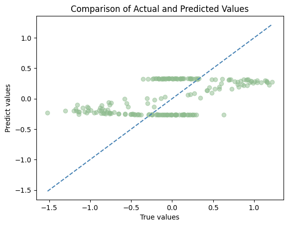

```python
y_pred = model.predict(x_test)
plt.scatter(y_test, y_pred, alpha=0.5, color="darkseagreen")
plt.plot([min(y_test), max(y_test)], [min(y_test), max(y_test)], color='steelblue', linestyle='--')
plt.xlabel('True values')
plt.ylabel('Predict values')
plt.title('Comparison of Actual and Predicted Values')
plt.show()
```

On voit qu'avec 1 neuronne, le modele ne predit pas de valeurs continue mais plutot 2 valeurs discretes entre 0,5 et -0,5

#### Observation 2 (Avec 30 neuronnes)

```
32/32 ━━━━━━━━━━━━━━━━━━━━ 1s 4ms/step - loss: 0.4572 - val_loss: 0.3442
32/32 ━━━━━━━━━━━━━━━━━━━━ 0s 2ms/step - loss: 0.2876 - val_loss: 0.3445
32/32 ━━━━━━━━━━━━━━━━━━━━ 0s 1ms/step - loss: 0.2824 - val_loss: 0.3422
32/32 ━━━━━━━━━━━━━━━━━━━━ 0s 1ms/step - loss: 0.2821 - val_loss: 0.3423
32/32 ━━━━━━━━━━━━━━━━━━━━ 0s 1ms/step - loss: 0.2708 - val_loss: 0.3410
32/32 ━━━━━━━━━━━━━━━━━━━━ 0s 1ms/step - loss: 0.2730 - val_loss: 0.3394
32/32 ━━━━━━━━━━━━━━━━━━━━ 0s 1ms/step - loss: 0.2755 - val_loss: 0.3412
32/32 ━━━━━━━━━━━━━━━━━━━━ 0s 1ms/step - loss: 0.2594 - val_loss: 0.3393
32/32 ━━━━━━━━━━━━━━━━━━━━ 0s 1ms/step - loss: 0.2800 - val_loss: 0.3391
32/32 ━━━━━━━━━━━━━━━━━━━━ 0s 1ms/step - loss: 0.2887 - val_loss: 0.3401
32/32 ━━━━━━━━━━━━━━━━━━━━ 0s 1ms/step - loss: 0.2724 - val_loss: 0.3366
32/32 ━━━━━━━━━━━━━━━━━━━━ 0s 1ms/step - loss: 0.2727 - val_loss: 0.3357
32/32 ━━━━━━━━━━━━━━━━━━━━ 0s 1ms/step - loss: 0.2818 - val_loss: 0.3357
32/32 ━━━━━━━━━━━━━━━━━━━━ 0s 1ms/step - loss: 0.2672 - val_loss: 0.3344
32/32 ━━━━━━━━━━━━━━━━━━━━ 0s 1ms/step - loss: 0.2702 - val_loss: 0.3329
32/32 ━━━━━━━━━━━━━━━━━━━━ 0s 3ms/step - loss: 0.2749 - val_loss: 0.3331
32/32 ━━━━━━━━━━━━━━━━━━━━ 0s 1ms/step - loss: 0.2838 - val_loss: 0.3343
32/32 ━━━━━━━━━━━━━━━━━━━━ 0s 1ms/step - loss: 0.2629 - val_loss: 0.3314
32/32 ━━━━━━━━━━━━━━━━━━━━ 0s 1ms/step - loss: 0.2844 - val_loss: 0.3314
32/32 ━━━━━━━━━━━━━━━━━━━━ 0s 1ms/step - loss: 0.2833 - val_loss: 0.3280
32/32 ━━━━━━━━━━━━━━━━━━━━ 0s 1ms/step - loss: 0.2756 - val_loss: 0.3269
32/32 ━━━━━━━━━━━━━━━━━━━━ 0s 1ms/step - loss: 0.2767 - val_loss: 0.3258
32/32 ━━━━━━━━━━━━━━━━━━━━ 0s 1ms/step - loss: 0.2663 - val_loss: 0.3233
32/32 ━━━━━━━━━━━━━━━━━━━━ 0s 1ms/step - loss: 0.2727 - val_loss: 0.3202
32/32 ━━━━━━━━━━━━━━━━━━━━ 0s 1ms/step - loss: 0.2638 - val_loss: 0.3205
32/32 ━━━━━━━━━━━━━━━━━━━━ 0s 1ms/step - loss: 0.2550 - val_loss: 0.3155
32/32 ━━━━━━━━━━━━━━━━━━━━ 0s 1ms/step - loss: 0.2649 - val_loss: 0.3110
32/32 ━━━━━━━━━━━━━━━━━━━━ 0s 1ms/step - loss: 0.2703 - val_loss: 0.3086
32/32 ━━━━━━━━━━━━━━━━━━━━ 0s 1ms/step - loss: 0.2533 - val_loss: 0.3054
32/32 ━━━━━━━━━━━━━━━━━━━━ 0s 1ms/step - loss: 0.2536 - val_loss: 0.3027
32/32 ━━━━━━━━━━━━━━━━━━━━ 0s 1ms/step - loss: 0.2530 - val_loss: 0.2953
32/32 ━━━━━━━━━━━━━━━━━━━━ 0s 1ms/step - loss: 0.2467 - val_loss: 0.2929
32/32 ━━━━━━━━━━━━━━━━━━━━ 0s 1ms/step - loss: 0.2451 - val_loss: 0.2884
32/32 ━━━━━━━━━━━━━━━━━━━━ 0s 1ms/step - loss: 0.2355 - val_loss: 0.2827
32/32 ━━━━━━━━━━━━━━━━━━━━ 0s 1ms/step - loss: 0.2314 - val_loss: 0.2776
32/32 ━━━━━━━━━━━━━━━━━━━━ 0s 1ms/step - loss: 0.2257 - val_loss: 0.2734
32/32 ━━━━━━━━━━━━━━━━━━━━ 0s 1ms/step - loss: 0.2210 - val_loss: 0.2623
32/32 ━━━━━━━━━━━━━━━━━━━━ 0s 1ms/step - loss: 0.2178 - val_loss: 0.2603
32/32 ━━━━━━━━━━━━━━━━━━━━ 0s 1ms/step - loss: 0.2167 - val_loss: 0.2498
32/32 ━━━━━━━━━━━━━━━━━━━━ 0s 1ms/step - loss: 0.2061 - val_loss: 0.2422
```

[output cut: 47 more lines]

```
32/32 ━━━━━━━━━━━━━━━━━━━━ 0s 1ms/step - loss: 0.1075 - val_loss: 0.1101
32/32 ━━━━━━━━━━━━━━━━━━━━ 0s 1ms/step - loss: 0.1057 - val_loss: 0.1098
32/32 ━━━━━━━━━━━━━━━━━━━━ 0s 1ms/step - loss: 0.1038 - val_loss: 0.1108
32/32 ━━━━━━━━━━━━━━━━━━━━ 0s 1ms/step - loss: 0.1022 - val_loss: 0.1095
32/32 ━━━━━━━━━━━━━━━━━━━━ 0s 1ms/step - loss: 0.1050 - val_loss: 0.1082
32/32 ━━━━━━━━━━━━━━━━━━━━ 0s 1ms/step - loss: 0.0977 - val_loss: 0.1065
32/32 ━━━━━━━━━━━━━━━━━━━━ 0s 2ms/step - loss: 0.1038 - val_loss: 0.1097
32/32 ━━━━━━━━━━━━━━━━━━━━ 0s 1ms/step - loss: 0.0944 - val_loss: 0.1062
32/32 ━━━━━━━━━━━━━━━━━━━━ 0s 1ms/step - loss: 0.0998 - val_loss: 0.1061
32/32 ━━━━━━━━━━━━━━━━━━━━ 0s 1ms/step - loss: 0.0975 - val_loss: 0.1082
32/32 ━━━━━━━━━━━━━━━━━━━━ 0s 1ms/step - loss: 0.1021 - val_loss: 0.1079
32/32 ━━━━━━━━━━━━━━━━━━━━ 0s 1ms/step - loss: 0.1040 - val_loss: 0.1088
32/32 ━━━━━━━━━━━━━━━━━━━━ 0s 1ms/step - loss: 0.0974 - val_loss: 0.1056
WARNING:tensorflow:5 out of the last 15 calls to <function TensorFlowTrainer.make_predict_function.<locals>.one_step_on_data_distributed at 0x159e5dee0> triggered tf.function retracing. Tracing is expensive and the excessive number of tracings could be due to (1) creating @tf.function repeatedly in …
7/7 ━━━━━━━━━━━━━━━━━━━━ 0s 4ms/step
```

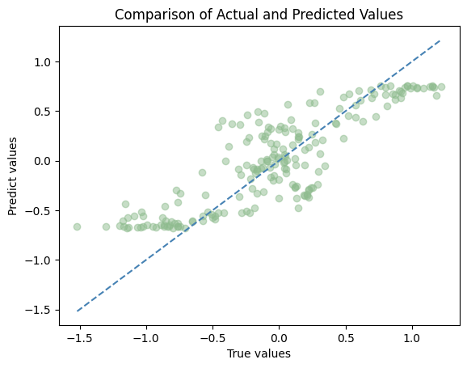

```python
# Model definition
model = models.Sequential()
model.add(layers.Dense(30, activation='tanh', input_shape=(1,))) # Hidden layer with tanh
model.add(layers.Dense(1)) # Output layer with no activation function
# Compile the model
model.compile(optimizer='adam', loss='mean_squared_error')
# Train the model
model.fit(x_train, y_train, epochs=100, batch_size=32, validation_data=(x_test, y_test))

y_pred = model.predict(x_test)
plt.scatter(y_test, y_pred, alpha=0.5, color="darkseagreen")
plt.plot([min(y_test), max(y_test)], [min(y_test), max(y_test)], color='steelblue', linestyle='--')
plt.xlabel('True values')
plt.ylabel('Predict values')
plt.title('Comparison of Actual and Predicted Values')
plt.show()
```

Il y a très peu de changements entre le modèle original avec 10 neuronnes et celui ci avec 30 neuronnes à part peut etre une meilleure prediction des valeurs autour de 0.

#### Observation 3 (Avec 2 neuronnes)

```
32/32 ━━━━━━━━━━━━━━━━━━━━ 1s 5ms/step - loss: 0.3511 - val_loss: 0.4257
32/32 ━━━━━━━━━━━━━━━━━━━━ 0s 2ms/step - loss: 0.3492 - val_loss: 0.3928
32/32 ━━━━━━━━━━━━━━━━━━━━ 0s 1ms/step - loss: 0.3197 - val_loss: 0.3669
32/32 ━━━━━━━━━━━━━━━━━━━━ 0s 1ms/step - loss: 0.2868 - val_loss: 0.3465
32/32 ━━━━━━━━━━━━━━━━━━━━ 0s 1ms/step - loss: 0.2687 - val_loss: 0.3289
32/32 ━━━━━━━━━━━━━━━━━━━━ 0s 1ms/step - loss: 0.2680 - val_loss: 0.3163
32/32 ━━━━━━━━━━━━━━━━━━━━ 0s 2ms/step - loss: 0.2438 - val_loss: 0.3051
32/32 ━━━━━━━━━━━━━━━━━━━━ 0s 1ms/step - loss: 0.2395 - val_loss: 0.2968
32/32 ━━━━━━━━━━━━━━━━━━━━ 0s 1ms/step - loss: 0.2552 - val_loss: 0.2891
32/32 ━━━━━━━━━━━━━━━━━━━━ 0s 1ms/step - loss: 0.2175 - val_loss: 0.2829
32/32 ━━━━━━━━━━━━━━━━━━━━ 0s 1ms/step - loss: 0.2272 - val_loss: 0.2785
32/32 ━━━━━━━━━━━━━━━━━━━━ 0s 1ms/step - loss: 0.2351 - val_loss: 0.2739
32/32 ━━━━━━━━━━━━━━━━━━━━ 0s 1ms/step - loss: 0.2319 - val_loss: 0.2693
32/32 ━━━━━━━━━━━━━━━━━━━━ 0s 1ms/step - loss: 0.2247 - val_loss: 0.2662
32/32 ━━━━━━━━━━━━━━━━━━━━ 0s 1ms/step - loss: 0.2244 - val_loss: 0.2621
32/32 ━━━━━━━━━━━━━━━━━━━━ 0s 1ms/step - loss: 0.2145 - val_loss: 0.2590
32/32 ━━━━━━━━━━━━━━━━━━━━ 0s 1ms/step - loss: 0.2269 - val_loss: 0.2550
32/32 ━━━━━━━━━━━━━━━━━━━━ 0s 1ms/step - loss: 0.2269 - val_loss: 0.2526
32/32 ━━━━━━━━━━━━━━━━━━━━ 0s 1ms/step - loss: 0.1967 - val_loss: 0.2497
32/32 ━━━━━━━━━━━━━━━━━━━━ 0s 1ms/step - loss: 0.2261 - val_loss: 0.2460
32/32 ━━━━━━━━━━━━━━━━━━━━ 0s 1ms/step - loss: 0.2100 - val_loss: 0.2427
32/32 ━━━━━━━━━━━━━━━━━━━━ 0s 1ms/step - loss: 0.1949 - val_loss: 0.2391
32/32 ━━━━━━━━━━━━━━━━━━━━ 0s 1ms/step - loss: 0.2049 - val_loss: 0.2358
32/32 ━━━━━━━━━━━━━━━━━━━━ 0s 1ms/step - loss: 0.2065 - val_loss: 0.2326
32/32 ━━━━━━━━━━━━━━━━━━━━ 0s 1ms/step - loss: 0.1903 - val_loss: 0.2299
32/32 ━━━━━━━━━━━━━━━━━━━━ 0s 1ms/step - loss: 0.1953 - val_loss: 0.2260
32/32 ━━━━━━━━━━━━━━━━━━━━ 0s 1ms/step - loss: 0.1932 - val_loss: 0.2224
32/32 ━━━━━━━━━━━━━━━━━━━━ 0s 1ms/step - loss: 0.1920 - val_loss: 0.2196
32/32 ━━━━━━━━━━━━━━━━━━━━ 0s 1ms/step - loss: 0.1932 - val_loss: 0.2165
32/32 ━━━━━━━━━━━━━━━━━━━━ 0s 2ms/step - loss: 0.1886 - val_loss: 0.2133
32/32 ━━━━━━━━━━━━━━━━━━━━ 0s 1ms/step - loss: 0.1912 - val_loss: 0.2094
32/32 ━━━━━━━━━━━━━━━━━━━━ 0s 1ms/step - loss: 0.1733 - val_loss: 0.2068
32/32 ━━━━━━━━━━━━━━━━━━━━ 0s 1ms/step - loss: 0.1786 - val_loss: 0.2032
32/32 ━━━━━━━━━━━━━━━━━━━━ 0s 1ms/step - loss: 0.1785 - val_loss: 0.1997
32/32 ━━━━━━━━━━━━━━━━━━━━ 0s 1ms/step - loss: 0.1721 - val_loss: 0.1964
32/32 ━━━━━━━━━━━━━━━━━━━━ 0s 1ms/step - loss: 0.1620 - val_loss: 0.1921
32/32 ━━━━━━━━━━━━━━━━━━━━ 0s 1ms/step - loss: 0.1522 - val_loss: 0.1900
32/32 ━━━━━━━━━━━━━━━━━━━━ 0s 1ms/step - loss: 0.1619 - val_loss: 0.1862
32/32 ━━━━━━━━━━━━━━━━━━━━ 0s 1ms/step - loss: 0.1587 - val_loss: 0.1828
32/32 ━━━━━━━━━━━━━━━━━━━━ 0s 1ms/step - loss: 0.1624 - val_loss: 0.1787
```

[output cut: 47 more lines]

```
32/32 ━━━━━━━━━━━━━━━━━━━━ 0s 1ms/step - loss: 0.0798 - val_loss: 0.0833
32/32 ━━━━━━━━━━━━━━━━━━━━ 0s 1ms/step - loss: 0.0848 - val_loss: 0.0823
32/32 ━━━━━━━━━━━━━━━━━━━━ 0s 1ms/step - loss: 0.0778 - val_loss: 0.0817
32/32 ━━━━━━━━━━━━━━━━━━━━ 0s 1ms/step - loss: 0.0755 - val_loss: 0.0813
32/32 ━━━━━━━━━━━━━━━━━━━━ 0s 1ms/step - loss: 0.0720 - val_loss: 0.0802
32/32 ━━━━━━━━━━━━━━━━━━━━ 0s 2ms/step - loss: 0.0768 - val_loss: 0.0795
32/32 ━━━━━━━━━━━━━━━━━━━━ 0s 1ms/step - loss: 0.0773 - val_loss: 0.0785
32/32 ━━━━━━━━━━━━━━━━━━━━ 0s 1ms/step - loss: 0.0731 - val_loss: 0.0781
32/32 ━━━━━━━━━━━━━━━━━━━━ 0s 2ms/step - loss: 0.0701 - val_loss: 0.0780
32/32 ━━━━━━━━━━━━━━━━━━━━ 0s 1ms/step - loss: 0.0727 - val_loss: 0.0765
32/32 ━━━━━━━━━━━━━━━━━━━━ 0s 1ms/step - loss: 0.0676 - val_loss: 0.0766
32/32 ━━━━━━━━━━━━━━━━━━━━ 0s 1ms/step - loss: 0.0686 - val_loss: 0.0765
32/32 ━━━━━━━━━━━━━━━━━━━━ 0s 1ms/step - loss: 0.0715 - val_loss: 0.0753
WARNING:tensorflow:5 out of the last 15 calls to <function TensorFlowTrainer.make_predict_function.<locals>.one_step_on_data_distributed at 0x15a3e19e0> triggered tf.function retracing. Tracing is expensive and the excessive number of tracings could be due to (1) creating @tf.function repeatedly in …
7/7 ━━━━━━━━━━━━━━━━━━━━ 0s 4ms/step
```

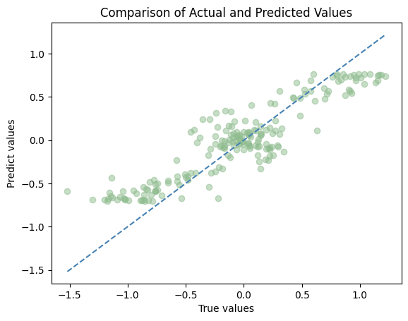

```python
# Model definition
model = models.Sequential()
model.add(layers.Dense(2, activation='tanh', input_shape=(1,))) # Hidden layer with tanh
model.add(layers.Dense(1)) # Output layer with no activation function
# Compile the model
model.compile(optimizer='adam', loss='mean_squared_error')
# Train the model
model.fit(x_train, y_train, epochs=100, batch_size=32, validation_data=(x_test, y_test))

y_pred = model.predict(x_test)
plt.scatter(y_test, y_pred, alpha=0.5, color="darkseagreen")
plt.plot([min(y_test), max(y_test)], [min(y_test), max(y_test)], color='steelblue', linestyle='--')
plt.xlabel('True values')
plt.ylabel('Predict values')
plt.title('Comparison of Actual and Predicted Values')
plt.show()
```

On peut remarquer une grande difference de précision entre un modèle à 1 neuronne et un modele avec 2 neuronnes.

#### Observation 4 (Avec 500 neuronnes)

```
32/32 ━━━━━━━━━━━━━━━━━━━━ 1s 5ms/step - loss: 0.3012 - val_loss: 0.3404
32/32 ━━━━━━━━━━━━━━━━━━━━ 0s 2ms/step - loss: 0.3126 - val_loss: 0.3472
32/32 ━━━━━━━━━━━━━━━━━━━━ 0s 2ms/step - loss: 0.2789 - val_loss: 0.3395
32/32 ━━━━━━━━━━━━━━━━━━━━ 0s 1ms/step - loss: 0.2806 - val_loss: 0.3388
32/32 ━━━━━━━━━━━━━━━━━━━━ 0s 1ms/step - loss: 0.2914 - val_loss: 0.3453
32/32 ━━━━━━━━━━━━━━━━━━━━ 0s 1ms/step - loss: 0.2934 - val_loss: 0.3488
32/32 ━━━━━━━━━━━━━━━━━━━━ 0s 1ms/step - loss: 0.3040 - val_loss: 0.3446
32/32 ━━━━━━━━━━━━━━━━━━━━ 0s 1ms/step - loss: 0.2754 - val_loss: 0.3440
32/32 ━━━━━━━━━━━━━━━━━━━━ 0s 1ms/step - loss: 0.2874 - val_loss: 0.3532
32/32 ━━━━━━━━━━━━━━━━━━━━ 0s 1ms/step - loss: 0.2932 - val_loss: 0.3402
32/32 ━━━━━━━━━━━━━━━━━━━━ 0s 2ms/step - loss: 0.2926 - val_loss: 0.3466
32/32 ━━━━━━━━━━━━━━━━━━━━ 0s 1ms/step - loss: 0.2846 - val_loss: 0.3410
32/32 ━━━━━━━━━━━━━━━━━━━━ 0s 1ms/step - loss: 0.3017 - val_loss: 0.3505
32/32 ━━━━━━━━━━━━━━━━━━━━ 0s 1ms/step - loss: 0.3140 - val_loss: 0.3409
32/32 ━━━━━━━━━━━━━━━━━━━━ 0s 1ms/step - loss: 0.2742 - val_loss: 0.3489
32/32 ━━━━━━━━━━━━━━━━━━━━ 0s 1ms/step - loss: 0.2769 - val_loss: 0.3443
32/32 ━━━━━━━━━━━━━━━━━━━━ 0s 1ms/step - loss: 0.2611 - val_loss: 0.3419
32/32 ━━━━━━━━━━━━━━━━━━━━ 0s 1ms/step - loss: 0.2728 - val_loss: 0.3457
32/32 ━━━━━━━━━━━━━━━━━━━━ 0s 1ms/step - loss: 0.2913 - val_loss: 0.3408
32/32 ━━━━━━━━━━━━━━━━━━━━ 0s 1ms/step - loss: 0.2958 - val_loss: 0.3382
32/32 ━━━━━━━━━━━━━━━━━━━━ 0s 1ms/step - loss: 0.2900 - val_loss: 0.3435
32/32 ━━━━━━━━━━━━━━━━━━━━ 0s 2ms/step - loss: 0.2760 - val_loss: 0.3386
32/32 ━━━━━━━━━━━━━━━━━━━━ 0s 1ms/step - loss: 0.2865 - val_loss: 0.3406
32/32 ━━━━━━━━━━━━━━━━━━━━ 0s 1ms/step - loss: 0.2742 - val_loss: 0.3420
32/32 ━━━━━━━━━━━━━━━━━━━━ 0s 1ms/step - loss: 0.2903 - val_loss: 0.3425
32/32 ━━━━━━━━━━━━━━━━━━━━ 0s 1ms/step - loss: 0.2853 - val_loss: 0.3410
32/32 ━━━━━━━━━━━━━━━━━━━━ 0s 1ms/step - loss: 0.2970 - val_loss: 0.3491
32/32 ━━━━━━━━━━━━━━━━━━━━ 0s 1ms/step - loss: 0.3050 - val_loss: 0.3472
32/32 ━━━━━━━━━━━━━━━━━━━━ 0s 1ms/step - loss: 0.2523 - val_loss: 0.3440
32/32 ━━━━━━━━━━━━━━━━━━━━ 0s 1ms/step - loss: 0.2765 - val_loss: 0.3408
32/32 ━━━━━━━━━━━━━━━━━━━━ 0s 1ms/step - loss: 0.2811 - val_loss: 0.3527
32/32 ━━━━━━━━━━━━━━━━━━━━ 0s 1ms/step - loss: 0.2745 - val_loss: 0.3403
32/32 ━━━━━━━━━━━━━━━━━━━━ 0s 1ms/step - loss: 0.2903 - val_loss: 0.3436
32/32 ━━━━━━━━━━━━━━━━━━━━ 0s 1ms/step - loss: 0.2810 - val_loss: 0.3487
32/32 ━━━━━━━━━━━━━━━━━━━━ 0s 1ms/step - loss: 0.2771 - val_loss: 0.3428
32/32 ━━━━━━━━━━━━━━━━━━━━ 0s 2ms/step - loss: 0.2792 - val_loss: 0.3419
32/32 ━━━━━━━━━━━━━━━━━━━━ 0s 2ms/step - loss: 0.2958 - val_loss: 0.3494
32/32 ━━━━━━━━━━━━━━━━━━━━ 0s 1ms/step - loss: 0.2851 - val_loss: 0.3456
32/32 ━━━━━━━━━━━━━━━━━━━━ 0s 1ms/step - loss: 0.2581 - val_loss: 0.3392
32/32 ━━━━━━━━━━━━━━━━━━━━ 0s 1ms/step - loss: 0.3012 - val_loss: 0.3413
```

[output cut: 46 more lines]

```
32/32 ━━━━━━━━━━━━━━━━━━━━ 0s 1ms/step - loss: 0.1775 - val_loss: 0.2059
32/32 ━━━━━━━━━━━━━━━━━━━━ 0s 1ms/step - loss: 0.1704 - val_loss: 0.1952
32/32 ━━━━━━━━━━━━━━━━━━━━ 0s 2ms/step - loss: 0.1578 - val_loss: 0.1988
32/32 ━━━━━━━━━━━━━━━━━━━━ 0s 1ms/step - loss: 0.1628 - val_loss: 0.1935
32/32 ━━━━━━━━━━━━━━━━━━━━ 0s 1ms/step - loss: 0.1541 - val_loss: 0.1758
32/32 ━━━━━━━━━━━━━━━━━━━━ 0s 1ms/step - loss: 0.1563 - val_loss: 0.1789
32/32 ━━━━━━━━━━━━━━━━━━━━ 0s 1ms/step - loss: 0.1636 - val_loss: 0.1763
32/32 ━━━━━━━━━━━━━━━━━━━━ 0s 1ms/step - loss: 0.1540 - val_loss: 0.1681
32/32 ━━━━━━━━━━━━━━━━━━━━ 0s 1ms/step - loss: 0.1481 - val_loss: 0.1639
32/32 ━━━━━━━━━━━━━━━━━━━━ 0s 1ms/step - loss: 0.1543 - val_loss: 0.1597
32/32 ━━━━━━━━━━━━━━━━━━━━ 0s 2ms/step - loss: 0.1454 - val_loss: 0.1624
32/32 ━━━━━━━━━━━━━━━━━━━━ 0s 2ms/step - loss: 0.1491 - val_loss: 0.1571
32/32 ━━━━━━━━━━━━━━━━━━━━ 0s 1ms/step - loss: 0.1504 - val_loss: 0.1702
32/32 ━━━━━━━━━━━━━━━━━━━━ 0s 1ms/step - loss: 0.1461 - val_loss: 0.1602
7/7 ━━━━━━━━━━━━━━━━━━━━ 0s 4ms/step
```

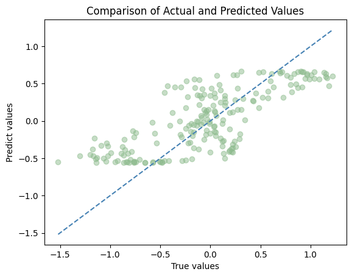

```python
# Model definition
model = models.Sequential()
model.add(layers.Dense(500, activation='tanh', input_shape=(1,))) # Hidden layer with tanh
model.add(layers.Dense(1)) # Output layer with no activation function
# Compile the model
model.compile(optimizer='adam', loss='mean_squared_error')
# Train the model
model.fit(x_train, y_train, epochs=100, batch_size=32, validation_data=(x_test, y_test))

y_pred = model.predict(x_test)
plt.scatter(y_test, y_pred, alpha=0.5, color="darkseagreen")
plt.plot([min(y_test), max(y_test)], [min(y_test), max(y_test)], color='steelblue', linestyle='--')
plt.xlabel('True values')
plt.ylabel('Predict values')
plt.title('Comparison of Actual and Predicted Values')
plt.show()
```